# 6. visualizing with lime using sklearn.ensemble.RandomForestClassifier no stop word removal

```python
!ls
```

```
'5. spark including pre-processing csv file to load into spark.ipynb'
'6. visualizing with lime.ipynb'
 nocommas_small_descr_clm_code.csv
 small_descr_clm_code.csv
 spark-warehouse
 work
```

```python
from pyspark.sql import SQLContext
from pyspark import SparkContext
```

```python
import pandas as pd
import numpy as np
import scipy.stats as scs
import statsmodels.api as sm
import matplotlib.pyplot as plt
import lime
import sklearn
import sklearn.ensemble
import sklearn.metrics
from __future__ import print_function

%matplotlib inline
%config InlineBackend.figure_format='retina'
```

```python
df = pd.read_csv('small_descr_clm_code.csv')
df.drop('Unnamed: 0',axis=1, inplace=True)
df.head()
```

|  | descr | clm | code |
| --- | --- | --- | --- |
| 0 | CROSS-REFERENCE TO RELATED APPLICATIONS \n ... | 1. A computer-implemented method of designing ... | 706 |
| 1 | RELATED APPLICATIONS \n This application i... | What is claimed is: \n \n 1 . A sy... | 705 |
| 2 | CROSS REFERENCE TO RELATED APPLICATION \n ... | 1. A weather information display device compri... | 706 |
| 3 | TECHNICAL FIELD \n The present disclosure ... | 1 . A method of obtaining a user&#39;s measure... | 705 |
| 4 | CROSS-REFERENCE TO RELATED APPLICATIONS \n ... | 1 . A method for providing borrower foreclosur... | 705 |

```python
def remove_string(dataframe,column_list,string_in_quotes):
    '''
    Input:
            dataframe: name of pandas dataframe
            column_list: list of column name strings (ex. ['col_1','col_2'])
            string_in_quotes: string to remove in quotes (ex. ',')

    Output:
            none
            modifies pandas dataframe to remove string.

    Example:
            remove_string(df, ['col_1','col_2'], ',')

    Warning:
            If memory issues occur, limit to one column at a time.

    '''
    for i in column_list:
        dataframe[i] = dataframe[i].str.replace(string_in_quotes,"").astype(str)
```

```python
remove_string(df, ['descr'],',')
```

```python
remove_string(df, ['clm'],',')
```

```python
remove_string(df, ['descr'],'\n')
```

```python
remove_string(df, ['clm'],'\n')
```

```python
df.iloc[0]['clm']
```

```
'1. A computer-implemented method of designing a set of experiments to be performed with a set of resources the method comprising: generating by a computer a plurality of configurations based on a set of parameters and experimental constraints each configuration including a plurality of experimental…
```

### Optimizing object types using categoricals

Pandas introduced Categoricals in version 0.15. The category type uses integer values under the hood to represent the values in a column, rather than the raw values. Pandas uses a separate mapping dictionary that maps the integer values to the raw ones. This arrangement is useful whenever a column contains a limited set of values. When we convert a column to the category dtype, pandas uses the most space efficient int subtype that can represent all of the unique values in a column. [citation](https://www.dataquest.io/blog/pandas-big-data/)

```python
df['code'] = df['code'].astype('category')
```

```python
df.info()
```

```
<class 'pandas.core.frame.DataFrame'>
RangeIndex: 5836 entries, 0 to 5835
Data columns (total 3 columns):
descr    5836 non-null object
clm      5836 non-null object
code     5836 non-null category
dtypes: category(1), object(2)
memory usage: 97.1+ KB
```

```python
df.info(memory_usage='deep')
```

```
<class 'pandas.core.frame.DataFrame'>
RangeIndex: 5836 entries, 0 to 5835
Data columns (total 3 columns):
descr    5836 non-null object
clm      5836 non-null object
code     5836 non-null category
dtypes: category(1), object(2)
memory usage: 879.4 MB
```

# Lime Visualization example with 2 class classifier (only using 'descr' column

```python
from sklearn.model_selection import train_test_split
X = df['descr']
y = df['code']
X_train, X_test, y_train, y_test = train_test_split(X, y, test_size=0.33, random_state=42, stratify=y)
```

```python
print(len(X))
print(X.shape)
```

```
5836
(5836,)
```

```python
print(len(y))
print(y.shape)
```

```
5836
(5836,)
```

```python
print(len(X_train))
print(X_train.shape)
```

```
3910
(3910,)
```

```python
print(len(y_train))
print(y_train.shape)
```

```
3910
(3910,)
```

```python
print(len(X_test))
print(X_test.shape)
```

```
1926
(1926,)
```

Let's use the tfidf vectorizer, commonly used for text.

```python
from sklearn import feature_extraction
vectorizer = sklearn.feature_extraction.text.TfidfVectorizer(lowercase=False)
train_vectors = vectorizer.fit_transform(X_train)
test_vectors = vectorizer.transform(X_test)
```

Now, let's say we want to use random forests for classification. It's usually hard to understand what random forests are doing, especially with many trees.

```python
rf = sklearn.ensemble.RandomForestClassifier(n_estimators=500)
rf.fit(train_vectors, y_train)  #rf.fit(train_vectors, newsgroups_train.target)
```

```
RandomForestClassifier(bootstrap=True, class_weight=None, criterion='gini',
            max_depth=None, max_features='auto', max_leaf_nodes=None,
            min_impurity_decrease=0.0, min_impurity_split=None,
            min_samples_leaf=1, min_samples_split=2,
            min_weight_fraction_leaf=0.0, n_estimators=500, n_jobs=1,
            oob_score=False, random_state=None, verbose=0,
            warm_start=False)
```

```python
from sklearn.metrics import roc_curve, auc, f1_score, recall_score, precision_score
pred = rf.predict(test_vectors)
sklearn.metrics.f1_score(y_test, pred, average=None)
```

```
array([ 0.92245989,  0.89179104])
```

```python
pred2 = rf.predict(test_vectors)
sklearn.metrics.f1_score(y_test, pred2, average='weighted')
```

```
0.90894075899675986
```

```python
pred3 = rf.predict(test_vectors)
sklearn.metrics.f1_score(y_test, pred3, average='binary')
```

[output not shown]

# Explaining predictions using lime

Lime explainers assume that classifiers act on raw text, but sklearn classifiers act on vectorized representation of texts. For this purpose, we use sklearn's pipeline, and implements predict_proba on raw_text lists.

```python
from lime import lime_text
from sklearn.pipeline import make_pipeline
c = make_pipeline(vectorizer, rf)
```

```python
print(c.predict_proba([X_test.iloc[0]]))
```

```
[[ 0.756  0.244]]
```

Now we create an explainer object. We pass the class_names a an argument for prettier display.

```python
from lime.lime_text import LimeTextExplainer
```

```python
class_names = ['705','706']
explainer = LimeTextExplainer(class_names=class_names)
```

We then generate an explanation with at most 6 features for an arbitrary document in the test set.

```python
idx = 83
exp = explainer.explain_instance(X_test.iloc[idx], c.predict_proba, num_features=6)
print('Document id: %d' % idx)
print('Probability(706) =', c.predict_proba([X_test.iloc[idx]])[0,1])
print('True class: %s' % y_test.iloc[idx])
```

```
Document id: 83
Probability(706) = 0.542
True class: 706
```

```python
print(y_test.iloc[idx])
```

```
706
```

```python
print(X_test.iloc[idx])
```

```
BACKGROUND      This invention relates to the field of process automation. In particular the invention relates to adaptive business process automation.      Business processes are often defined as a flow sequence of operations on a single or set of systems or applications. This flow is composed of i…
```

```python
exp.as_list()
```

```
[('transactions', -0.014035703909663355),
 ('state', 0.013395462750129178),
 ('learning', 0.013297253897952782),
 ('patterns', 0.012469462757559944),
 ('is', 0.012192835521796874),
 ('the', -0.0097426326533752682)]
```

from docs of lime: These weighted features are a linear model, which approximates the behaviour of the random forest classifier in the vicinity of the test example. Roughly, if we remove 'Posting' and 'Host' from the document , the prediction should move towards the opposite class (Christianity) by about 0.27 (the sum of the weights for both features). Let's see if this is the case. [citation](https://marcotcr.github.io/lime/tutorials/Lime%20-%20basic%20usage%2C%20two%20class%20case.html)

try

```python
print('Original prediction:', rf.predict_proba(test_vectors[idx])[0,1])
tmp = test_vectors[idx].copy()
tmp[0,vectorizer.vocabulary_['transactions']] = 0
tmp[0,vectorizer.vocabulary_['state']] = 0
print('Prediction removing some features:', rf.predict_proba(tmp)[0,1])
print('Difference:', rf.predict_proba(tmp)[0,1] - rf.predict_proba(test_vectors[idx])[0,1])
```

```
Original prediction: 0.542
Prediction removing some features: 0.542
Difference: 0.0
```

**They probably were not worth much. I need to do word removal or work with n-grams**

# Visualizing explanations

The explanations can be returned as a matplotlib barplot:

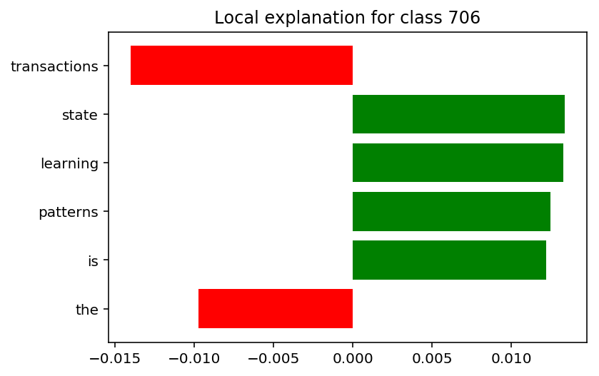

```python
fig = exp.as_pyplot_figure()
```

The explanations can also be exported as an html page (which we can render here in this notebook), using D3.js to render graphs.

```python
exp.show_in_notebook(text=False)
```

[output not shown]

Alternatively, we can save the fully contained html page to a file:

```python
exp.save_to_file('/tmp/oi.html')
```

```python
exp.show_in_notebook(text=True)
```

[output not shown]

# this explainer works for any classifier you may want to use, as long as it implements **predict_proba**.

# spark (description and class only)

```python
sc =SparkContext()
sqlContext = SQLContext(sc)
data = sqlContext.read.format('com.databricks.spark.csv').options(header='true', inferschema='true').load('nocommas_small_descr_clm_code.csv')
```

```python
data.show(5)
```

```
+---+--------------------+--------------------+----+
|_c0|               descr|                 clm|code|
+---+--------------------+--------------------+----+
|  0|CROSS-REFERENCE T...|1. A computer-imp...| 706|
|  1|RELATED APPLICATI...|What is claimed i...| 705|
|  2|CROSS REFERENCE T...|1. A weather info...| 706|
|  3|TECHNICAL FIELD  ...|1 . A method of o...| 705|
|  4|CROSS-REFERENCE T...|1 . A method for ...| 705|
+---+--------------------+--------------------+----+
only showing top 5 rows
```

```python
drop_list = ['_c0','clm']
data = data.select([column for column in data.columns if column not in drop_list])
data.show(5)
```

```
+--------------------+----+
|               descr|code|
+--------------------+----+
|CROSS-REFERENCE T...| 706|
|RELATED APPLICATI...| 705|
|CROSS REFERENCE T...| 706|
|TECHNICAL FIELD  ...| 705|
|CROSS-REFERENCE T...| 705|
+--------------------+----+
only showing top 5 rows
```

```python
data.printSchema()
```

```
root
 |-- descr: string (nullable = true)
 |-- code: integer (nullable = true)
```

```python
from pyspark.sql.functions import col
```

```python
data.groupBy("code") \
    .count() \
    .orderBy(col("count").desc()) \
    .show()
```

```
+----+-----+
|code|count|
+----+-----+
| 705| 3264|
| 706| 2572|
+----+-----+
```

# visualize

```python
!pip install lime
```

```
    100% |████████████████████████████████| 276kB 754kB/s ta 0:00:01
  Running setup.py bdist_wheel for lime ... done
You are using pip version 9.0.3, however version 18.1 is available.
```

```python
from pyspark.ml.feature import RegexTokenizer, StopWordsRemover, CountVectorizer
from pyspark.ml.classification import LogisticRegression
```

```python
# regular expression tokenizer
regexTokenizer = RegexTokenizer(inputCol="descr", outputCol="words", pattern="\\W")
```

```python
# stop words
#add_stopwords = ["http","https","amp","rt","t","c","the"]

stopwordsRemover = StopWordsRemover(inputCol="words", outputCol="filtered") #.setStopWords(add_stopwords)
```

```python
# bag of words count
countVectors = CountVectorizer(inputCol="filtered", outputCol="features", vocabSize=10000, minDF=5)
```

```python
from pyspark.ml import Pipeline
from pyspark.ml.feature import OneHotEncoder, StringIndexer, VectorAssembler
```

```python
label_stringIdx = StringIndexer(inputCol = "code", outputCol = "label")
pipeline = Pipeline(stages=[regexTokenizer, stopwordsRemover, countVectors, label_stringIdx])
```

```python
# Fit the pipeline to training documents.
pipelineFit = pipeline.fit(data)
dataset = pipelineFit.transform(data)
dataset.show(5)
```

```
+--------------------+----+--------------------+--------------------+--------------------+-----+
|               descr|code|               words|            filtered|            features|label|
+--------------------+----+--------------------+--------------------+--------------------+-----+
|CROSS-REFERENCE T...| 706|[cross, reference...|[cross, reference...|(10000,[0,1,2,3,4...|  1.0|
|RELATED APPLICATI...| 705|[related, applica...|[related, applica...|(10000,[0,1,2,3,4...|  0.0|
|CROSS REFERENCE T...| 706|[cross, reference...|[cross, reference...|(10000,[0,1,2,3,4...|  1.0|
|TECHNICAL FIELD  ...| 705|[technical, field...|[technical, field...|(10000,[0,1,2,3,4...|  0.0|
|CROSS-REFERENCE T...| 705|[cross, reference...|[cross, reference...|(10000,[0,1,2,3,4...|  0.0|
+--------------------+----+--------------------+--------------------+--------------------+-----+
only showing top 5 rows
```

```python
(trainingData, testData) = dataset.randomSplit([0.7, 0.3], seed = 100)
print("Training Dataset Count: " + str(trainingData.count()))
print("Test Dataset Count: " + str(testData.count()))
```

```
Training Dataset Count: 4074
Test Dataset Count: 1762
```

# Logistic Regression using Count Vector Features

```python
lr = LogisticRegression(maxIter=20, regParam=0.3, elasticNetParam=0)
lrModel = lr.fit(trainingData)
predictions = lrModel.transform(testData)
predictions.filter(predictions['prediction'] == 0) \
    .select("descr","code","probability","label","prediction") \
    .orderBy("probability", ascending=False) \
    .show(n = 10, truncate = 30)
```

```
+------------------------------+----+------------------------------+-----+----------+
|                         descr|code|                   probability|label|prediction|
+------------------------------+----+------------------------------+-----+----------+
|CROSS-REFERENCE TO RELATED ...| 705|[0.9999999999999978,2.15987...|  0.0|       0.0|
|RELATED APPLICATIONS      T...| 705|[0.9999999999999964,3.55952...|  0.0|       0.0|
|CROSS-REFERENCE TO RELATED ...| 706|[0.9999999999992508,7.49208...|  1.0|       0.0|
|CROSS-REFERENCE TO RELATED ...| 705|[0.9999999999962543,3.74558...|  0.0|       0.0|
|BENEFIT CLAIM/RELATED APPLI...| 705|[0.9999999992964421,7.03557...|  0.0|       0.0|
|RELATED APPLICATIONS      T...| 705|[0.9999999973907547,2.60924...|  0.0|       0.0|
|CROSS-REFERENCE TO RELATED ...| 705|[0.9999999964717783,3.52822...|  0.0|       0.0|
|RELATED APPLICATION      Th...| 705|[0.999999987111588,1.288841...|  0.0|       0.0|
|CROSS-REFERENCE TO RELATED ...| 705|[0.9999998397314326,1.60268...|  0.0|       0.0|
|BACKGROUND      In the past...| 705|[0.9999996975073688,3.02492...|  0.0|       0.0|
+------------------------------+----+------------------------------+-----+----------+
only showing top 10 rows
```

```python
from pyspark.ml.evaluation import MulticlassClassificationEvaluator
```

```python
evaluator = MulticlassClassificationEvaluator(predictionCol="prediction")
evaluator.evaluate(predictions) #accuracy
```

```
0.9112954329109868
```

# Logistic Regression using TF-IDF Features

```python
from pyspark.ml.feature import HashingTF, IDF
```

```python
hashingTF = HashingTF(inputCol="filtered", outputCol="rawFeatures", numFeatures=10000)
idf = IDF(inputCol="rawFeatures", outputCol="features", minDocFreq=5) #minDocFreq: remove sparse terms
pipeline = Pipeline(stages=[regexTokenizer, stopwordsRemover, hashingTF, idf, label_stringIdx])
pipelineFit = pipeline.fit(data)
```

```python
dataset = pipelineFit.transform(data)
(trainingData, testData) = dataset.randomSplit([0.7, 0.3], seed = 100)
```

```python
lr = LogisticRegression(maxIter=20, regParam=0.3, elasticNetParam=0)
lrModel = lr.fit(trainingData)
```

```python
predictions = lrModel.transform(testData)
```

```python
predictions.filter(predictions['prediction'] == 0) \
    .select("descr","code","probability","label","prediction") \
    .orderBy("probability", ascending=False) \
    .show(n = 10, truncate = 30)
```

```
+------------------------------+----+------------------------------+-----+----------+
|                         descr|code|                   probability|label|prediction|
+------------------------------+----+------------------------------+-----+----------+
|RELATED APPLICATIONS      T...| 705|  [1.0,5.0803394142694484E-17]|  0.0|       0.0|
|CROSS-REFERENCE TO RELATED ...| 705|[0.9999999998574274,1.42572...|  0.0|       0.0|
|CROSS-REFERENCE TO RELATED ...| 705|[0.9999999996822633,3.17736...|  0.0|       0.0|
|RELATED APPLICATIONS      T...| 705|[0.9999999982645915,1.73540...|  0.0|       0.0|
|BENEFIT CLAIM/RELATED APPLI...| 705|[0.9999999955758205,4.42417...|  0.0|       0.0|
|CROSS-REFERENCE TO RELATED ...| 705|[0.9999999862068616,1.37931...|  0.0|       0.0|
|PRIORITY CLAIM      This ap...| 705|[0.9999999849488452,1.50511...|  0.0|       0.0|
|RELATED APPLICATIONS      T...| 705|[0.9999999701371722,2.98628...|  0.0|       0.0|
|CROSS-REFERENCE TO RELATED ...| 705|[0.9999997301433285,2.69856...|  0.0|       0.0|
|CROSS-REFERENCE TO RELATED ...| 705|[0.9999991369423112,8.63057...|  0.0|       0.0|
+------------------------------+----+------------------------------+-----+----------+
only showing top 10 rows
```

```python
evaluator = MulticlassClassificationEvaluator(predictionCol="prediction")
evaluator.evaluate(predictions)
```

```
0.9056256247015763
```

# Cross-Validation

```python
pipeline = Pipeline(stages=[regexTokenizer, stopwordsRemover, countVectors, label_stringIdx])
pipelineFit = pipeline.fit(data)
```

```python
dataset = pipelineFit.transform(data)
(trainingData, testData) = dataset.randomSplit([0.7, 0.3], seed = 100)
```

```python
lr = LogisticRegression(maxIter=20, regParam=0.3, elasticNetParam=0)
from pyspark.ml.tuning import ParamGridBuilder, CrossValidator
# Create ParamGrid for Cross Validation
```

```python
paramGrid = (ParamGridBuilder()
             .addGrid(lr.regParam, [0.1, 0.3, 0.5]) # regularization parameter
             .addGrid(lr.elasticNetParam, [0.0, 0.1, 0.2]) # Elastic Net Parameter (Ridge = 0)
#            .addGrid(model.maxIter, [10, 20, 50]) #Number of iterations
#            .addGrid(idf.numFeatures, [10, 100, 1000]) # Number of features
             .build())
```

```python
# Create 5-fold CrossValidator
cv = CrossValidator(estimator=lr, \
                    estimatorParamMaps=paramGrid, \
                    evaluator=evaluator, \
                    numFolds=5)
cvModel = cv.fit(trainingData)
```

[output not shown]

[output not shown]

[output cut: 29 more lines]

[output not shown]

```python
predictions = cvModel.transform(testData)
```

### accuracy

```python
# Evaluate best model
evaluator = MulticlassClassificationEvaluator(predictionCol="prediction")
evaluator.evaluate(predictions)
```

[output not shown]

# Naive Bayes

```python
from pyspark.ml.classification import NaiveBayes
```

```python
nb = NaiveBayes(smoothing=1)
model = nb.fit(trainingData)
```

```python
predictions = model.transform(testData)
```

```python
predictions.filter(predictions['prediction'] == 0) \
    .select("Descript","Category","probability","label","prediction") \
    .orderBy("probability", ascending=False) \
    .show(n = 10, truncate = 30)
```

[output not shown]

### accuracy

```python
evaluator = MulticlassClassificationEvaluator(predictionCol="prediction")
evaluator.evaluate(predictions)
```

[output not shown]

# Random Forest

```python
from pyspark.ml.classification import RandomForestClassifier
```

```python
rf = RandomForestClassifier(labelCol="label", \
                            featuresCol="features", \
                            numTrees = 100, \
                            maxDepth = 4, \
                            maxBins = 32)
```

```python
# Train model with Training Data
rfModel = rf.fit(trainingData)
```

```python
predictions = rfModel.transform(testData)
```

```python
predictions.filter(predictions['prediction'] == 0) \
    .select("Descript","Category","probability","label","prediction") \
    .orderBy("probability", ascending=False) \
    .show(n = 10, truncate = 30)
```

[output not shown]

### accuracy

```python
evaluator = MulticlassClassificationEvaluator(predictionCol="prediction")
evaluator.evaluate(predictions)
```

[output not shown]